# Tutorial 1: R Markdown

Daria Kuznetsova, University of Canterbury

## More about RMarkdown

As you can see, it is much easier to leave comments in RMarkdown file than in R script. Although R scripts are usefull and are still commonly used, RMarkdown files provide us with a better interface for the purposes of this class. Using R Markdown, we can write own annotated code for data visualisations, provide descriptions, and generate professionally looking output files as pdf, html, or word documents. RMarkdown file will be our default option for this class. You will submit your problem sets by inlcuding RMarkdown file and a PDF created with it.

For a very comprehensive list of capabilities of RMarkdown see this cheatsheet https://rstudio.github.io/cheatsheets/rmarkdown.pdf

## Anscombe’s Quartet

Now, let’s make our first visualisation! RStudio and its libraries provide built-in datasets that we will use in addition to other data. Let’s explore some of the options. To view all the datasets available we need to run the function `data()`.

```r
data()
```

Let’s use dataset “anscombe” that contains the Anscombe’s Quartet of ‘Identical’ Simple Linear Regressions. We saw these data visualised during our first lecture in class. But, before we continue, we need to load tidyverse library.

```r
library(tidyverse)
library(ggplot2)
```

```r
data("anscombe")
anscombe
```

```
##    x1 x2 x3 x4    y1   y2    y3    y4
## 1  10 10 10  8  8.04 9.14  7.46  6.58
## 2   8  8  8  8  6.95 8.14  6.77  5.76
## 3  13 13 13  8  7.58 8.74 12.74  7.71
## 4   9  9  9  8  8.81 8.77  7.11  8.84
## 5  11 11 11  8  8.33 9.26  7.81  8.47
## 6  14 14 14  8  9.96 8.10  8.84  7.04
## 7   6  6  6  8  7.24 6.13  6.08  5.25
## 8   4  4  4 19  4.26 3.10  5.39 12.50
## 9  12 12 12  8 10.84 9.13  8.15  5.56
## 10  7  7  7  8  4.82 7.26  6.42  7.91
## 11  5  5  5  8  5.68 4.74  5.73  6.89
```

```r
summary(anscombe)
```

```
##        x1             x2             x3             x4           y1
##  Min.   : 4.0   Min.   : 4.0   Min.   : 4.0   Min.   : 8   Min.   : 4.260
##  1st Qu.: 6.5   1st Qu.: 6.5   1st Qu.: 6.5   1st Qu.: 8   1st Qu.: 6.315
##  Median : 9.0   Median : 9.0   Median : 9.0   Median : 8   Median : 7.580
##  Mean   : 9.0   Mean   : 9.0   Mean   : 9.0   Mean   : 9   Mean   : 7.501
##  3rd Qu.:11.5   3rd Qu.:11.5   3rd Qu.:11.5   3rd Qu.: 8   3rd Qu.: 8.570
##  Max.   :14.0   Max.   :14.0   Max.   :14.0   Max.   :19   Max.   :10.840
##        y2              y3              y4
##  Min.   :3.100   Min.   : 5.39   Min.   : 5.250
##  1st Qu.:6.695   1st Qu.: 6.25   1st Qu.: 6.170
##  Median :8.140   Median : 7.11   Median : 7.040
##  Mean   :7.501   Mean   : 7.50   Mean   : 7.501
##  3rd Qu.:8.950   3rd Qu.: 7.98   3rd Qu.: 8.190
##  Max.   :9.260   Max.   :12.74   Max.   :12.500
```

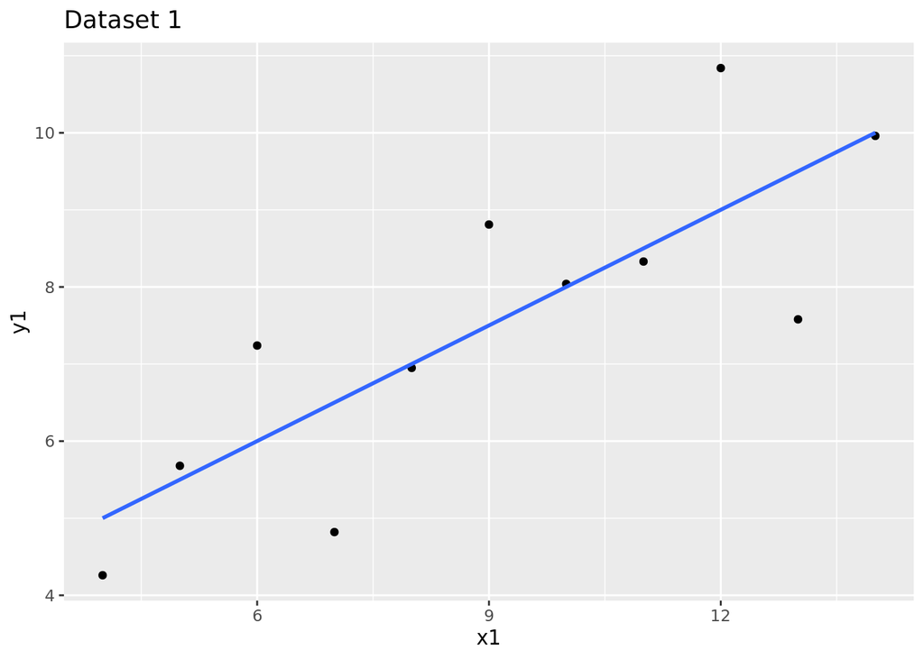

```r
p1 <- ggplot(data = anscombe, mapping = aes(x = x1, y = y1)) + # specify your data, x and y variables
      geom_point() +                                           # choose geometry to plot
      geom_smooth(method='lm', se = FALSE) +                   # adding linear trend
      labs(x = "x1", y = "y1",
        title = "Dataset 1" )                                  # adding axes labels and a title for our graph

p1
```

You just made your first graph with ggplot! Let’s break down the syntax.

Now, let’s create scatterplots (this is the type of plots we are making) for datasets 2, 3, and 4.

```r
p2 <- ggplot(data = anscombe, mapping = aes(x = x2, y = y2)) +
      geom_point() +
      geom_smooth(method='lm', se = FALSE) +
      labs(x = "x2", y = "y2",
        title = "Dataset 2" )

p3 <- ggplot(data = anscombe, mapping = aes(x = x3, y = y3)) +
      geom_point() +
      geom_smooth(method='lm', se = FALSE) +
      labs(x = "x3", y = "y3",
        title = "Dataset 3" )

p4 <- ggplot(data = anscombe, mapping = aes(x = x4, y = y4)) +
      geom_point() +
      geom_smooth(method='lm', se = FALSE) +
      labs(x = "x4", y = "y4",
        title = "Dataset 4" )
```

You will notice that this code does not produce any graphs. This is because we assigned graphs to objects `p2` `p3` and `p4`, but did not call these objects. Now, let’s combine our plots together. We will need to install package `patchwork` to combine our plots. Don’t forget to load the library after you install it.

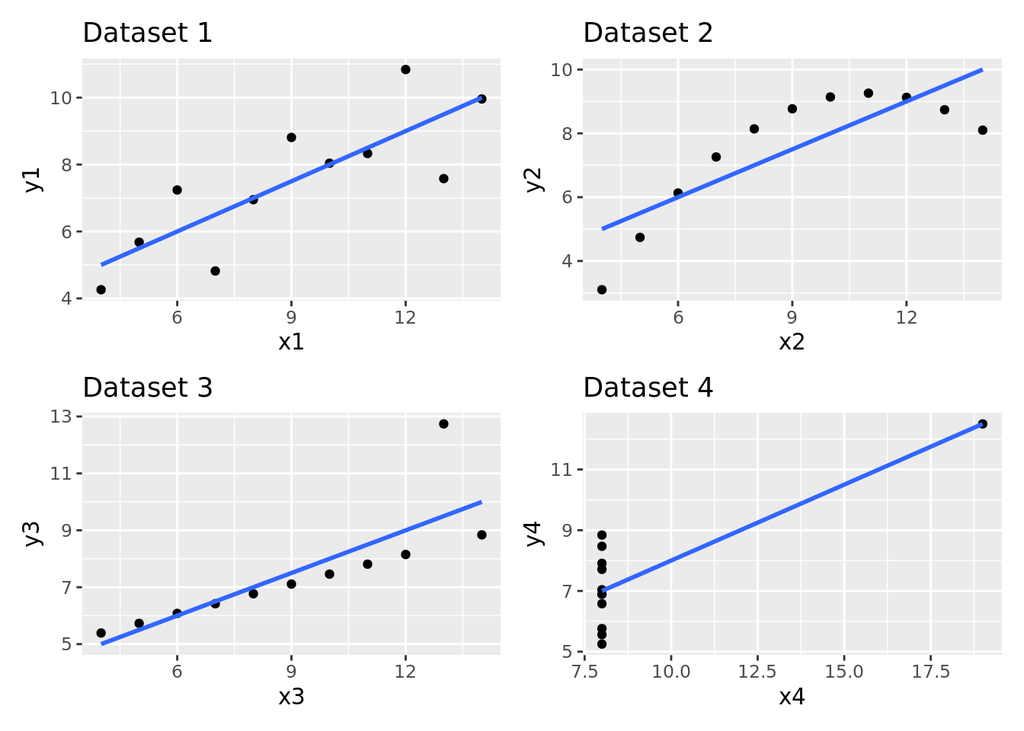

```r
#install.packages("patchwork")
library(patchwork)
p1+p2+p3+p4 +
  plot_layout(ncol = 2)
```

Do you like how these graphs look? What can we improve?

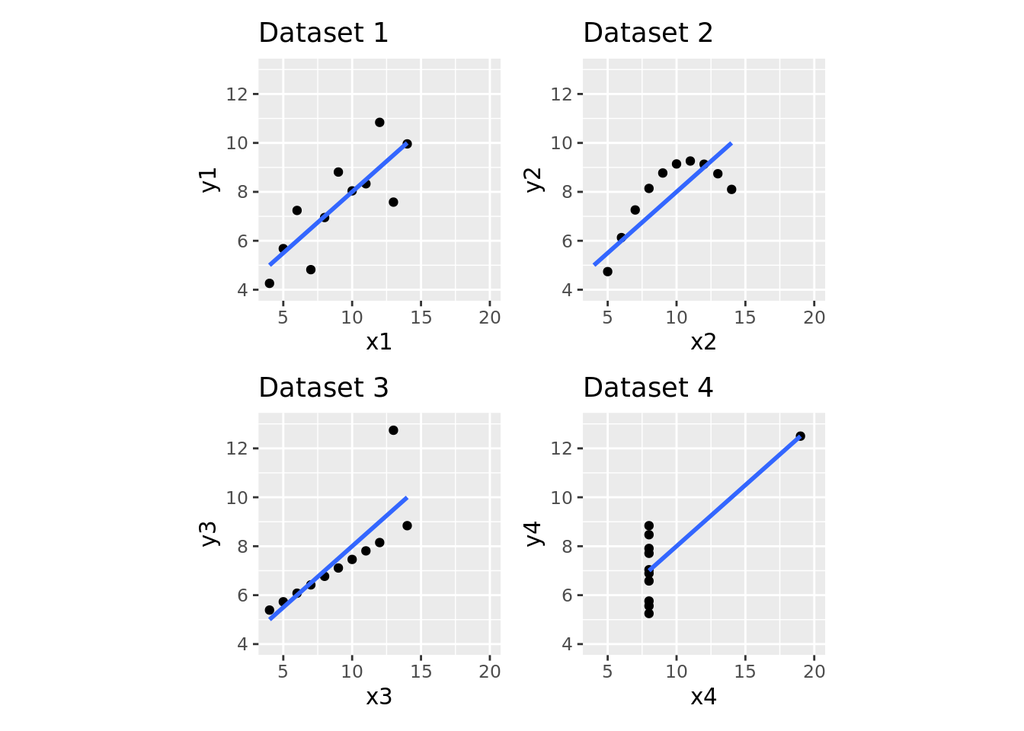

```r
p1 <- ggplot(data = anscombe, mapping = aes(x = x1, y = y1)) +
      geom_point() +
      geom_smooth(method='lm', se = FALSE) +
      coord_cartesian(xlim = c(4, 20), ylim = c(4, 13)) +
      theme(aspect.ratio = 1) +
      labs(x = "x1", y = "y1",
        title = "Dataset 1" )

p2 <- ggplot(data = anscombe, mapping = aes(x = x2, y = y2)) +
      geom_point() +
      geom_smooth(method='lm', se = FALSE) +
      coord_cartesian(xlim = c(4, 20), ylim = c(4, 13)) +
      theme(aspect.ratio = 1) +
      labs(x = "x2", y = "y2",
        title = "Dataset 2" )

p3 <- ggplot(data = anscombe, mapping = aes(x = x3, y = y3)) +
      geom_point() +
      geom_smooth(method='lm', se = FALSE) +
      coord_cartesian(xlim = c(4, 20), ylim = c(4, 13)) +
      theme(aspect.ratio = 1) +
      labs(x = "x3", y = "y3",
        title = "Dataset 3" )

p4 <- ggplot(data = anscombe, mapping = aes(x = x4, y = y4)) +
      geom_point() +
      geom_smooth(method='lm', se = FALSE) +
      coord_cartesian(xlim = c(4, 20), ylim = c(4, 13)) +
      theme(aspect.ratio = 1) +
      labs(x = "x4", y = "y4",
        title = "Dataset 4" )

p1+p2+p3+p4 +
  plot_layout(ncol = 2)
```

This looks better: the axes are consistent, and each graph is now a square.

## NZ population data

Next, let’s plot New Zealand population data. First, we need to load and explore our data.

```r
nz_pop <- read_csv("NZ STAT population estimates.csv") # load our data
```

[output not shown]

```r
nz_pop_2023 <- select(nz_pop, Area, `2023`) # select two columns to keep: region names and data for year 2023
# column names should not start with numeric symbols. But, for the sake of an example, we will go with it.
# We can # enclose 2023 in `` to select that column
nz_pop_2023 <- nz_pop_2023[2:18,] # keep values for regions only, remove total and totals for islands
```

Looks good! Now, our dataset has total population for each region in New Zealand in 2023. Let’s plot it. What type of a graph would you choose?

I will plot a bar chart.

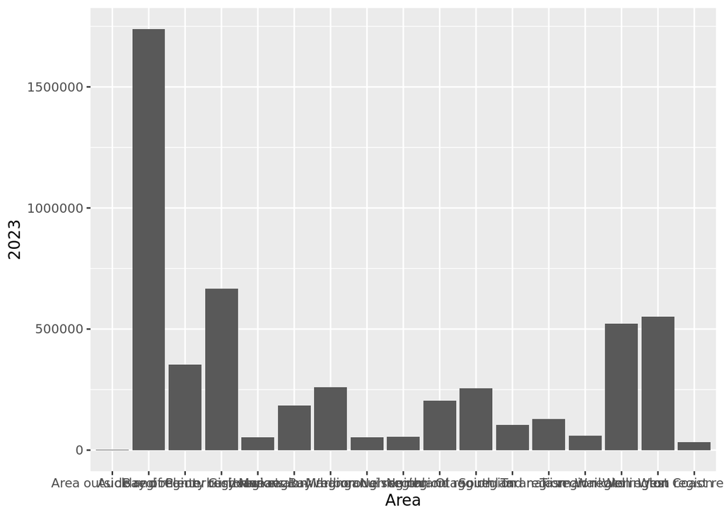

```r
plot_nz <- ggplot(nz_pop_2023, aes(Area, `2023`)) +
          geom_col()

plot_nz
```

How does this look?

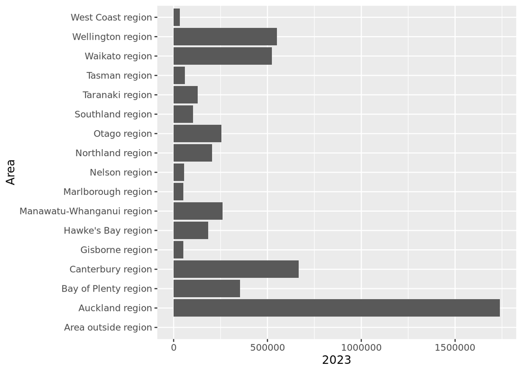

```r
plot_nz2 <- ggplot(nz_pop_2023, aes(y = Area, x = `2023`)) +
            geom_col()

plot_nz2
```

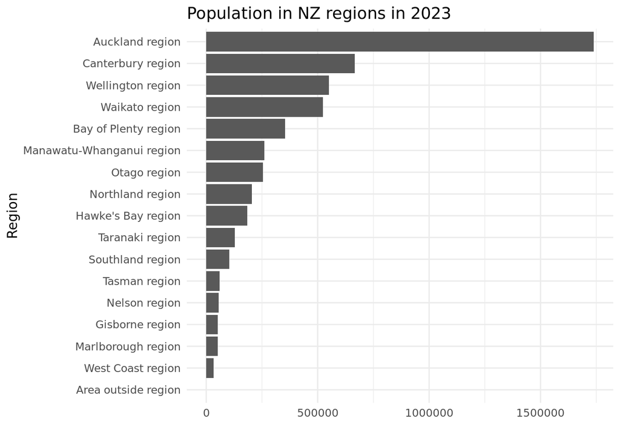

```r
# a bit more improvements

plot_nz3 <- ggplot(nz_pop_2023, aes(y = reorder(Area, `2023`), x = `2023`)) + # reorder function
                                                                              # helps to order the bars
            geom_col() +
            labs(x = "", y = "Region",
              title = "Population in NZ regions in 2023" ) +
            theme_minimal()                                                   # trying minimal theme instead of a default (theme_gray())

plot_nz3
```

# Now, your turn!

1. Create a new R Markdown file and provide a file description.
2. Load ggplot2 library.
3. Using `data("iris")` command load Iris data.
4. Explore the dataset.
5. Create a simple scatterplot of the data using `geom_point()` function.
6. Create scatterplot #2 using the same `geom_point()` function and adding a linear trend.
7. Create scatterplot #3 by adding color to the scatterplot #2 to differentiate between species by adding `color = Species` into aes parentheses. Do not forget to add a comma.
8. Display plots 2 and 3 together side by side, similarly to the example with Anscombe’s quartet above.
9. What else would you change in this graph?
10. Knit you RMarkdown file into a pdf and check your work. Make sure that all your code is included in the file with the images.

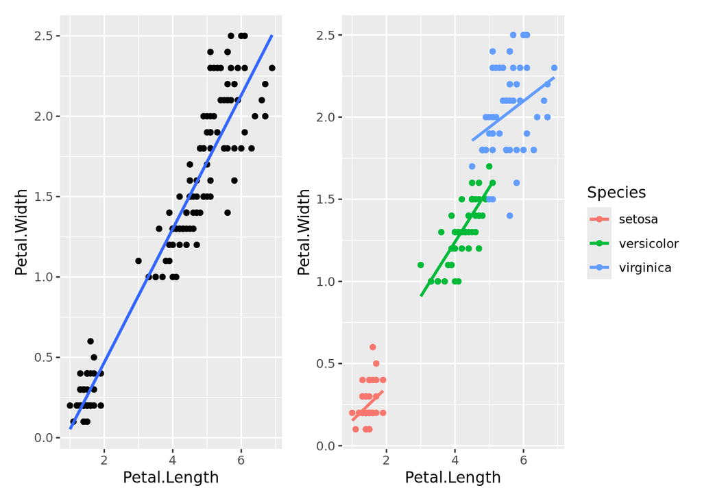

```r
library(ggplot2)
data("iris")
#iris

iris1 <- ggplot(data = iris, mapping = aes(x = Petal.Length, y = Petal.Width)) +
      geom_point()

iris2 <- ggplot(data = iris, mapping = aes(x = Petal.Length, y = Petal.Width)) +
      geom_point()  +
      geom_smooth(method="lm", se=F)


iris3 <- ggplot(data = iris, mapping = aes(x = Petal.Length,
                                  y = Petal.Width,
                                  color = Species)) +
      geom_point() +
      geom_smooth(method="lm", se=F)

iris2+iris3
```